# SQL and R

Nick Oliver

# Movie Ratings Database, SQL, and R

The data was loaded into a SQLite database which allows for flat file storage of the data in the `movie_ratings.db` file located in this directory.

For more information about how the `movie_ratings.db` was created and populated with data please refer to the `readme.md` file in this directory. This file also contains the original source links for all of the data that was collected.

## Movie Ratings Dataset

The movie ratings data is structured using 3 tables.

1. A movie table which contains information about the movie.
2. A reviewers table which contains reviewer information
3. A ratings table which contains foreign keys for both the movie id and the reviewer id along with the actual rating the user gave to the movie

Here is the data set in its entirety

Movie Ratings Dataset

|  | id | movie_name | release_date | director | runtime_minutes | budget_dollars | box_office_dollars | rating | username | user_display_name |
| --- | --- | --- | --- | --- | --- | --- | --- | --- | --- | --- |
| 1 | 1 | Soul | 2020-10-11 | Pete Doctor | 100 | 1.5e+08 | 119300000 | 4.5 | kurstboy | karsten |
| 2 | 1 | Soul | 2020-10-11 | Pete Doctor | 100 | 1.5e+08 | 119300000 | 3.5 | bratpitt | BRAT |
| 3 | 1 | Soul | 2020-10-11 | Pete Doctor | 100 | 1.5e+08 | 119300000 | 4.5 | jay | Jay |
| 4 | 1 | Soul | 2020-10-11 | Pete Doctor | 100 | 1.5e+08 | 119300000 | 4.0 | deathproof | Lucy |
| 5 | 1 | Soul | 2020-10-11 | Pete Doctor | 100 | 1.5e+08 | 119300000 | NA | sapphicquinn | ♦️•Lily•💋 |
| 6 | 2 | Soul | 2020-10-11 | Pete Doctor | 100 | 1.5e+08 | 119300000 | 3.5 | kurstboy | karsten |
| 7 | 2 | Soul | 2020-10-11 | Pete Doctor | 100 | 1.5e+08 | 119300000 | 2.5 | bratpitt | BRAT |
| 8 | 2 | Soul | 2020-10-11 | Pete Doctor | 100 | 1.5e+08 | 119300000 | 4.5 | jay | Jay |
| 9 | 2 | Soul | 2020-10-11 | Pete Doctor | 100 | 1.5e+08 | 119300000 | 3.0 | deathproof | Lucy |
| 10 | 2 | Soul | 2020-10-11 | Pete Doctor | 100 | 1.5e+08 | 119300000 | NA | sapphicquinn | ♦️•Lily•💋 |
| 11 | 3 | Tenet | 2020-09-03 | Christopher Nolan | 150 | 2.0e+08 | 363700000 | 4.5 | kurstboy | karsten |
| 12 | 3 | Tenet | 2020-09-03 | Christopher Nolan | 150 | 2.0e+08 | 363700000 | 3.5 | bratpitt | BRAT |
| 13 | 3 | Tenet | 2020-09-03 | Christopher Nolan | 150 | 2.0e+08 | 363700000 | 4.0 | jay | Jay |
| 14 | 3 | Tenet | 2020-09-03 | Christopher Nolan | 150 | 2.0e+08 | 363700000 | 2.5 | deathproof | Lucy |
| 15 | 3 | Tenet | 2020-09-03 | Christopher Nolan | 150 | 2.0e+08 | 363700000 | 3.0 | sapphicquinn | ♦️•Lily•💋 |
| 16 | 4 | Nomadland | 2021-02-19 | Chloé Zhao | 108 | 5.0e+06 | 27000000 | 3.5 | kurstboy | karsten |
| 17 | 4 | Nomadland | 2021-02-19 | Chloé Zhao | 108 | 5.0e+06 | 27000000 | 2.5 | bratpitt | BRAT |
| 18 | 4 | Nomadland | 2021-02-19 | Chloé Zhao | 108 | 5.0e+06 | 27000000 | 4.5 | jay | Jay |
| 19 | 4 | Nomadland | 2021-02-19 | Chloé Zhao | 108 | 5.0e+06 | 27000000 | 2.0 | deathproof | Lucy |
| 20 | 4 | Nomadland | 2021-02-19 | Chloé Zhao | 108 | 5.0e+06 | 27000000 | 3.5 | sapphicquinn | ♦️•Lily•💋 |
| 21 | 5 | Promising Young Woman | 2020-12-25 | Emerald Fennell | 108 | 1.0e+07 | 16700000 | 4.5 | kurstboy | karsten |
| 22 | 5 | Promising Young Woman | 2020-12-25 | Emerald Fennell | 108 | 1.0e+07 | 16700000 | 3.0 | bratpitt | BRAT |
| 23 | 5 | Promising Young Woman | 2020-12-25 | Emerald Fennell | 108 | 1.0e+07 | 16700000 | 3.0 | jay | Jay |
| 24 | 5 | Promising Young Woman | 2020-12-25 | Emerald Fennell | 108 | 1.0e+07 | 16700000 | 2.5 | deathproof | Lucy |
| 25 | 5 | Promising Young Woman | 2020-12-25 | Emerald Fennell | 108 | 1.0e+07 | 16700000 | 4.0 | sapphicquinn | ♦️•Lily•💋 |

## Graphing

As you can see the data above contains empty values due to not every reviewer having seeing every film. I represented this by allowing nulls in the ratings table and inserting records for those users with null ratings. This is a bit of a contrived example because in the real world I would have just not inserted those records.

Graphing the data set without removing those null records resulted in a warning. In order to handle this I used the `drop_na()` function of the `tidyr` library.

Below is a boxplot with the distribution of ratings for each movie from our users.

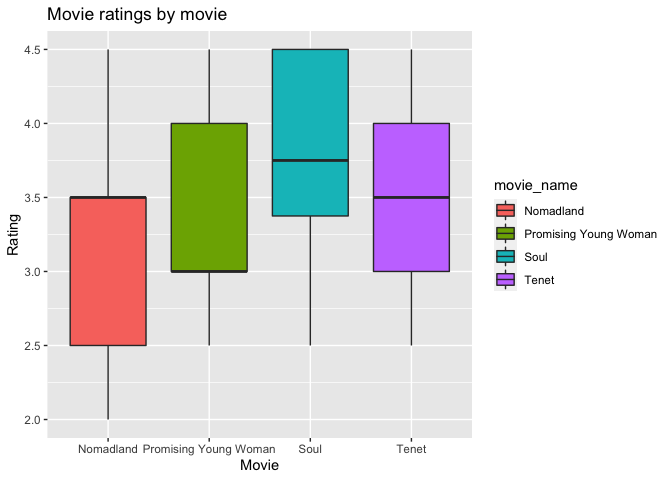